# Analyzing the Corpora

Alexey Serdyuk

9 June 2019

This is a part of the capstone project for the cycle of courses [Data Science Specialization](https://www.coursera.org/specializations/jhu-data-science) offered on [Coursera](https://www.coursera.org) by [Johns Hopkins University](https://www.jhu.edu).

We assume that the corpora were already downloaded and preprocessed.

We load the required libraries.

```r
library(data.table) # For fast data tables (extension of data frames).
library(quanteda) # For handling the corpora.
library(readr) # For fast reading/writing.
library(ggplot2) # For charts.
library(ggforce) # For charts.
library(grid) # For arranging charts in a grid.
library(gridExtra) # For arranging charts in a grid.
library(kableExtra) # For formatting tables.
```

We define a function that creates a Corpus from the specified file, where each line is transformed to a separate document.

```r
loadCorpus <- function(fileName) {
    # Read file into a character vector.
    text <- read_lines(fileName)

    # Create a Corpus from the character vector.
    corpus(text)
}
```

Using just defined function, we load pre-processed corpora.

```r
blogs.corpus <- loadCorpus("data-split/blogs.training.pre.txt")
news.corpus <- loadCorpus("data-split/news.training.pre.txt")
twitter.corpus <- loadCorpus("data-split/twitter.training.pre.txt")
```

## Distribution of bigrams

In this section we will study distribution bigrams, that is combinations of two words.

We define two helper functions. The first one creates a Document Feature Matrix (DFM) for n-grams in documents, and aggregates it over all documents to a Feature Vector. The second helper function enriches the Feature Vector with additional values useful for our analysis, such as cumulated coverage of text.

```r
# Calculate Document Feature Matrix (DFM) for n-grams in documents, and aggregate
# it over all documents to a Feature Vector.
build.ngram.fv <- function(text.corpus, n) {
    text.ngrams <- tokens(text.corpus, ngrams = n, concatenator = " ")
    text.dfm <- dfm(text.ngrams)
    colSums(text.dfm)
}

# Sorts a Feature Vector in descending order of frequency and enriches it with
# additional columns:
#  * Cumulated frequency of terms (words or n-grams)
#  * Cumulated frequency as percentage of total.
enrich.fv <- function(fv) {
    # Transform Feature Vector to a table and sort by frequency descending.
    tbl <- data.table(Terms = names(fv), Freq = fv)
    tbl <- tbl[order(-Freq)]

    # Add columns with cumulative frequency as a number of words, and as percentage.
    tbl$Freq.Cum <- cumsum(tbl$Freq)
    tbl$Freq.Pct <- tbl$Freq.Cum / sum(tbl$Freq)

    return (tbl)
}
```

Now we may calculate frequency of bigrams in each source, as well as in all sources together (aggregated).

```r
blogs.2gram.freq <- enrich.fv(build.ngram.fv(blogs.corpus, 2))
news.2gram.freq <- enrich.fv(build.ngram.fv(news.corpus, 2))
twitter.2gram.freq <- enrich.fv(build.ngram.fv(twitter.corpus, 2))
all.2gram.freq <- enrich.fv(build.ngram.fv(blogs.corpus + news.corpus + twitter.corpus, 2))
```

The following chart displays 20 most-frequent bigrams in each source, as well as in the aggregated corpora.

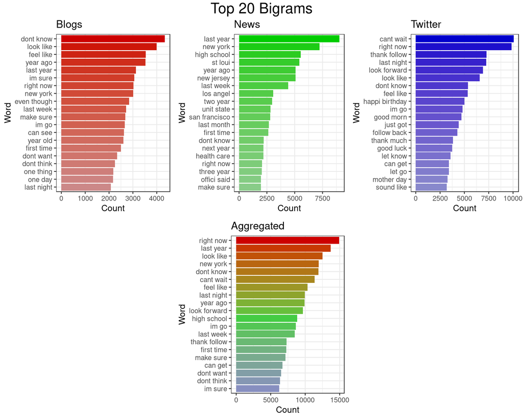

Similar to how we proceed with words, now we will analyze intersections, that is we will find how many bigrams are common to all sources, and how many are unique to a particular source. We also calculate a percentage of the whole source covered by a particular subset of all bigrams.

The following [Venn diagram](https://en.wikipedia.org/wiki/Venn_diagram) shows a number of unique bigrams used in each source, as well as a percentage of the aggregated corpora covered by those bigrams.

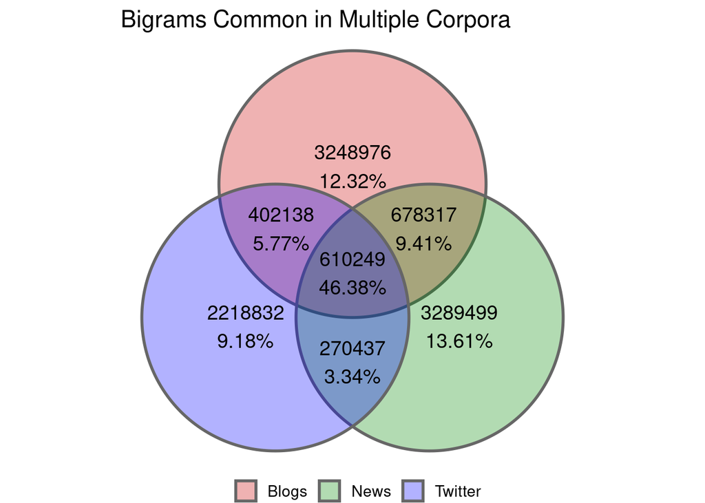

The next step in our analysis is to find out how many common bigrams we should choose to achieve a decent coverage of the text.

The following chart shows a number of unique bigrams in each source which cover particular percentage of the text. For example, 1000 most-frequent bigrams cover 8.41% of the Twitter corpus.

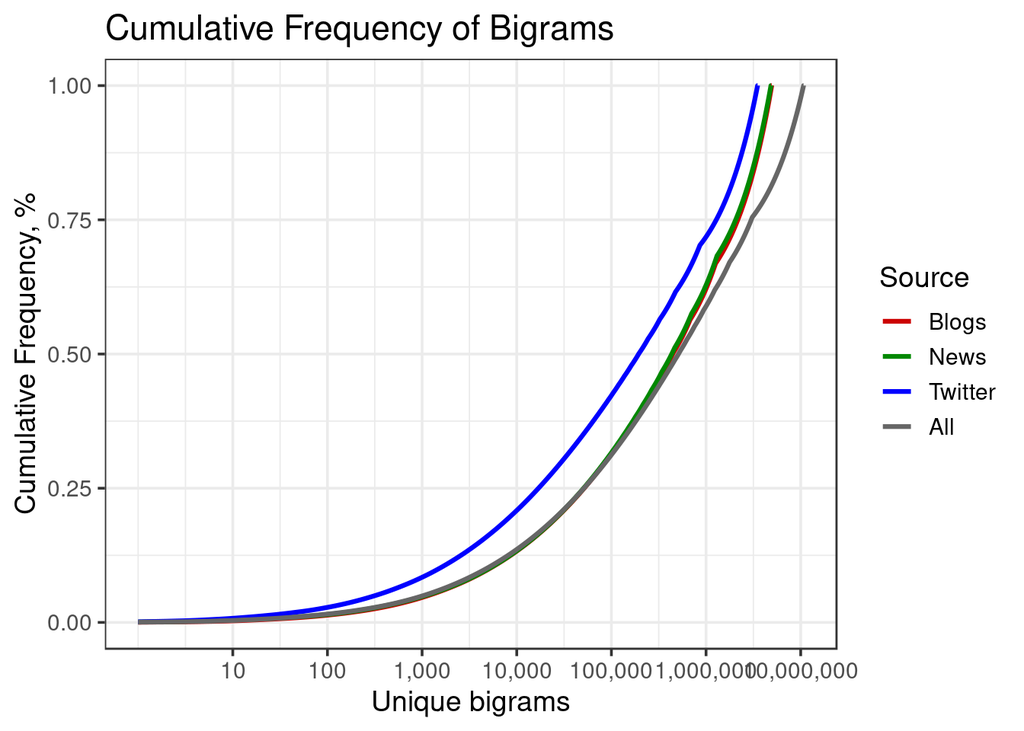

| Corpora Coverage | Blogs | News | Twitter | Aggregated |
| --- | --- | --- | --- | --- |
| 75% | 2163672 | 2055105 | 1281764 | 3003667 |
| 90% | 3829276 | 3731143 | 2613699 | 7602729 |
| 95% | 4384478 | 4289822 | 3057677 | 9160588 |
| 99% | 4828639 | 4736766 | 3412860 | 10406876 |
| 99.9% | 4928575 | 4837328 | 3492776 | 10687290 |

The table shows that in order to cover 95% of blogs, we require 4384478 bigrams The same coverage of news require 4289822 bigrams, and the coverage of twitter 3057677 bigrams To cover 95% of the aggregated corpora, we require 9160588 bigrams.